# 第6回 ルールを変えると、協力は変わるか

経済プログラミング特論II

第6回

ルールを変えると、  
協力は変わるか

協力の数と皆の受け取り、効き目の出どころ

経済プログラミング特論II

第6回 — Topic01

行動仮定と条件付き協力

人の代わりに書いたルールが、社会の動きを決める

## 前の回と今回の地図

2026年度のデータ

前の回：公共財

1 点出すと、自分は 0.6 減り  
4 人の合計では 0.6 増える  
教室の平均は 2 ラウンドで 8.80 → 7.19

今回：ルールのほうを変える

人の代わりにルールを書いた社会で  
罰を足す・罰への反応を止めて比べる  
罰の手間（費用）を変える

- **ずれ**：自分の得と皆の得は、1 点ごとに逆を向く
- **ルール**：持ち点 20（毎ラウンド配り直す）。4 人の箱の合計を 1.6 倍し、4 人で等分
- **あなたの役**：罰のルールを加えた実験を企画し、結果を読んで報告する人

## 今日の道のり

**今日のゴール**：分析する人として、罰を足すと協力は増えるか、皆は得をするかに答える  
罰で消えた点を引いて数え、1 つずつ止めて比べる

1

罰なしの社会を回す

実習：写経 4 人の班を回す

実習：実行 100 人の社会

演習 1 割合を 1.0 に

2

罰の帳簿をつける

実習：写経 班の帳簿

実習：実行 罰ありの帳簿

演習 2 班を替える

3

反応を止めて比べる

実習：写経 反応だけ止める

実習：実行 3 つの社会の図

演習 3 受けた人だけ反応

4

費用と持ち出し方

実習：写経 費用を 4 通りに

演習 4 費用 22 と 1 文

いまココ。人の代わりにルールを書いて、**罰のない社会を回す**

## このトピックで学ぶこと

2026年度のデータ

- **ここまで**：前の回で、自分の得と皆の得は 1 点ごとに逆を向くと分かった  
  あなたの教室の平均も、実験の日の 2 ラウンドで 8.80 → 7.19 と下がった
- **でも**：あなたの教室で、ルールだけ変えて何度もやり直すことはできない
- **問い**：分析する人として、罰なしで続けたら、協力が  
  下がり続けるのか、どこかで止まるのかを確かめる
- **見るもの**：ラウンドごとの平均拠出の線と、止まる高さ  
  止まる高さが分かると、報告の「比べる相手」が書ける
- **進め方**：前半は 4 人の班を手で、後半は 100 人の社会を Colab で

そこで、人の代わりに**ルールを書いて**、罰のない社会を回してみる

## 罰のない社会の平均拠出

他の人の平均に合わせて出す人が 6 割の社会で  
罰なしに 10 ラウンド続けると、平均拠出は

- **①** 上がる
- **②** ほぼ同じ
- **③** 下がる

動画を止めて、①〜③から 1 つ選んで、少し考えてから再生

## 4 人の班の 3 ラウンド

まず 4 人で、手で追う。同じ 4 人で 3 ラウンド（組み直さない）  
最初の 15 と割合 0.8 は、作る人が決めた数

[figure not shown]

STEP 1予想：前のラウンドの、他の 3 人の平均（最初は 15）

STEP 2拠出：予想 × 合わせる割合 0.8（最初は 0.8 × 15 ＝ 12）

B の 2 回目(0 ＋ 12 ＋ 20) ÷ 3 ＝ 10.67 → × 0.8 ＝ 8.53

## 4 人の班の床

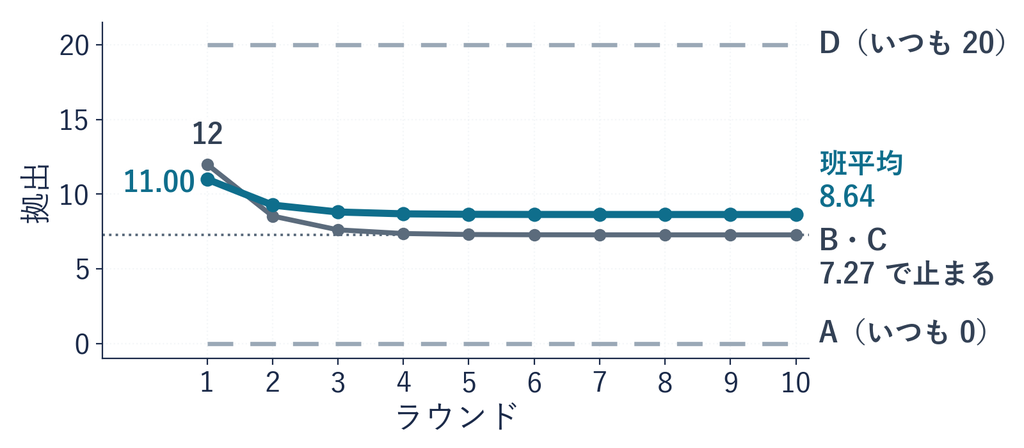

- **下がる**：A の 0 が他の 3 人の平均を下げ、× 0.8 でさらに控えめ
- **止まる**：D のいつも 20 が床（それより下がらない高さ）になり  
  B と C は 7.27 より下がらない

## 行動仮定

**行動仮定：モデルの人は、作る人が書いたとおりに動く**

定義

**行動仮定**モデルの中の人がどう選ぶかを  
作る人が決めて書いたルール  
人数の割合も含む  
（班なら 1・2・1 人、100 人なら 30・60・10 人）

- **ただ乗り型**：いつも 0 を出す（班の A）
- **条件付き協力型**：他の 3 人の平均 × 合わせる割合 0.8（B と C）
- **無条件協力型**：いつも 20 を出す（D）

下がって止まる動きは、書いたルールと人数の割合から出てくる

## Q&A

2026年度のデータ

Q1 本物の人で実験したほうが、確かでは？

人を集め、長く付き合ってもらうので、実験の日は **1 日だけ**  
モデルなら ① 集める手間も費用も要らない  
② **人の組み合わせや条件を変えて、何度でも試せる**

Q2 ルールが作る人の仮定なら、何が困る？

教室の 1 ラウンド目、0 点は **49 人中 8 人（16%）**  
このあと回すモデルのただ乗り型は 30%（作る人が置いた割合）  
割合を書き換えると、別の社会になる（演習 1 で確かめる）

モデルの結果は、書いたルールと一緒に読む

## 100 人の社会の内訳

今度は 100 人で、同じ決め方を。毎ラウンド 4 人組を組み直す

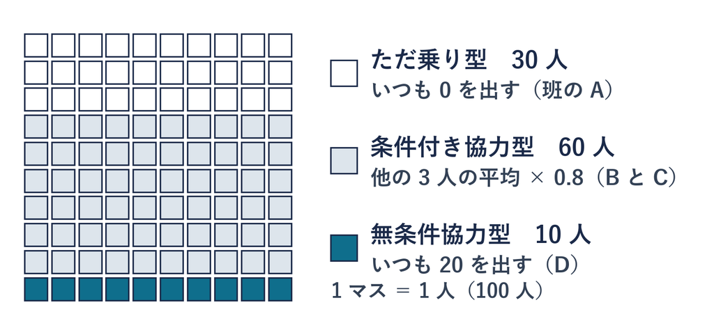

1 ラウンド目の平均拠出

$0.3 \times 0 + 0.6 \times 12 + 0.1 \times 20$

$= 9.2$

型の割合 × その型の拠出

## 罰なしの 10 ラウンド

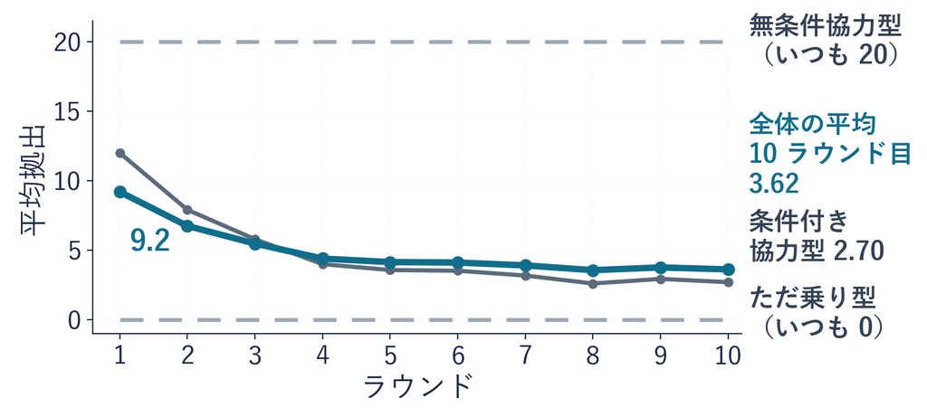

平均拠出は 9.2 → 10 ラウンド目 3.62（入口の答えは ③）

4 人の班の床 7.27 より低い：毎ラウンド組み直すので  
25 組のうち 15〜19 組に、いつも 20 の人がいない

## 罰なしの社会の 2 つの数

平均拠出（10 ラウンドの平均）

4.89

受け取り（10 ラウンドの平均）

22.94

- **受け取り**：20 ＋ 0.6 × 平均拠出（平均 11 なら 20 ＋ 6.6 ＝ 26.6）
- **3.62 と 4.89**：3.62 は 10 ラウンド目だけ、4.89 は 10 ラウンドの平均
- **比べる相手**：この回は、ずっとこの罰なしの社会と比べる

拠出 4.89・受け取り 22.94 が、今日の比べる相手の 2 つの数

## 4 人の班のループの写経

```python
guess = [15, 15, 15, 15]                       # 4人の予想（最初は15）
for t in range(3):                             # 3ラウンド
    c = [0, 0.8 * guess[1], 0.8 * guess[2], 20]  # A・B・C・D の拠出
    print(t + 1, [round(x, 2) for x in c], round(sum(c) / 4, 2))
    guess = [(sum(c) - x) / 3 for x in c]      # 他の3人の平均
```

| 行 | 部品 | 中身 |
| --- | --- | --- |
| 1 | **① 予想の箱** | 4 人の予想を並べたリスト（最初は 4 人とも 15） |
| 2 | **② 繰り返し** | 3 ラウンド回す（t は 0・1・2） |
| 3 | **③ 拠出の 1 行** | A は 0・B と C は 予想 × 0.8・D は 20 （guess[1] が B。番号は 0 から） |
| 4 | **④ 表示** | ラウンド・4 人の拠出・班平均（round で小数 2 桁） |
| 5 | **⑤ 予想の 1 行** | 合計から自分の点を引いて 3 で割る＝他の 3 人の平均 |

## 4 人の班のループの実行

1. 準備のセルを ▶ してから  
   **＋ コード**でセルを足す
2. p.14 のコードを  
   上から写す
3. **▶** か **Shift + Enter** で実行  
   （Mac は Shift + return）
4. 3 行の出力で  
   班平均を見る

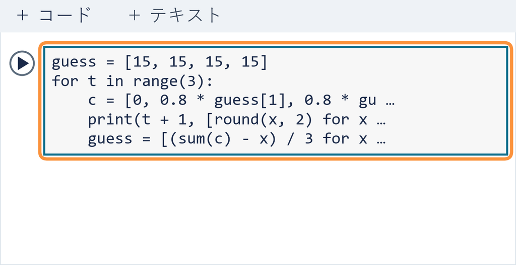

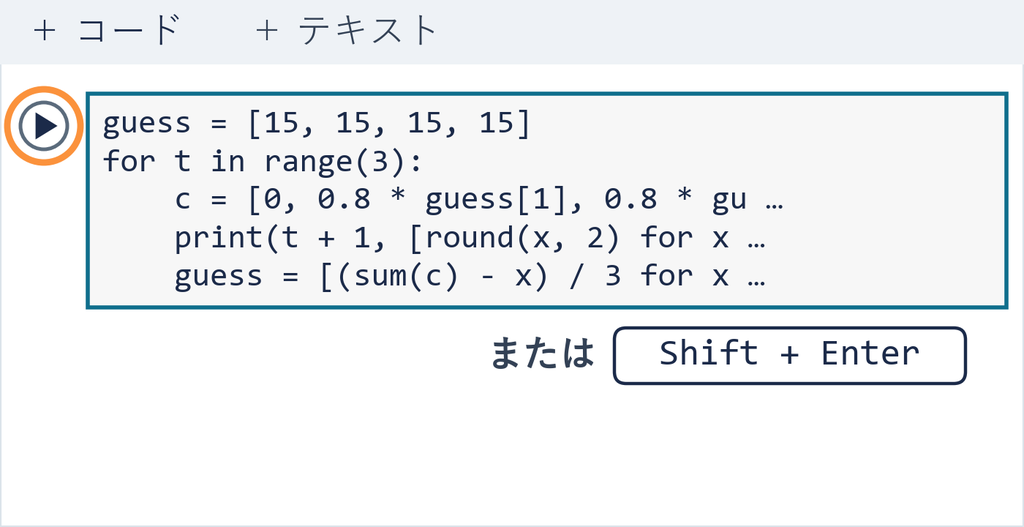

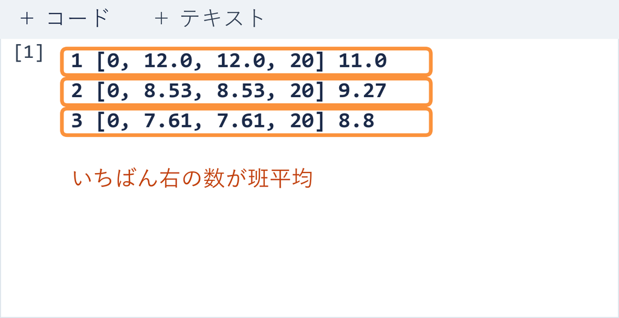

⏸ PAUSE 動画を止めて $5$ 分。3 行が出たら再生に戻る

## 100 人の社会の実行

```python
def mean_of(rec, key):                 # 10ラウンドの平均（小数2桁）
    return round(sum(r[key] for r in rec) / len(rec), 2)

rec = society()                        # 100人・罰なし
print("拠出:", mean_of(rec, "contribution"),
      " 受け取り:", mean_of(rec, "gross"))
```

ノート段 1 の【そのまま実行】のセル。写さずに選んで ▶（準備のセルを先に）  
rec＝10 ラウンドの記録のリスト・“gross”＝受け取り

出力 拠出: 4.89 受け取り: 22.94

⏸ PAUSE 動画を止めて $2$ 分。1 行が出たら再生に戻る

## 演習 1 合わせる割合の変更

p.16 の出力 拠出: 4.89 受け取り: 22.94

演習 1

合わせる割合を 1.0 にすると、平均拠出は 4.89 より上がるか

```python
rec = society()                        # ← ここを書き換える
print("拠出:", mean_of(rec, "contribution"),
      " 受け取り:", mean_of(rec, "gross"))
```

1. **書き換える**：**＋ コード**で足したセルに 3 行を写し  
   1 行目を rec = society(beta=1.0) に（beta は合わせる割合）
2. **予想する**：平均拠出は p.16 の 4.89 と比べて  
   （上がる／ほぼ同じ／下がる）
3. **終わり**：1 行が出たら、答え欄に 2 つの数を書く

⏸ PAUSE 動画を止めて $5$ 分。1 行が出たら再生に戻る

## 演習 1 の答え

rec = society(beta=1.0)  
拠出: 6.59 受け取り: 23.96

- **平均拠出**：4.89 → 6.59 に上がる（受け取り 22.94 → 23.96）
- ラウンドを追うと**下がって止まる**のは同じ：1 ラウンド目 11.0 → 10 ラウンド目 4.80  
  （ただ乗り型の 0 が平均を下げる）

書いた割合を 1 か所変えると、別の社会になる

## まとめ

- **行動仮定**：モデルの人は、作る人が書いたとおりに動く
- **4 人の班**：班平均 11.00 → 9.27 → 8.80（D の 20 が床）
- **100 人の社会**：罰なしの拠出 4.89・受け取り 22.94（比べる相手）

分析する人として言えること：書いたルールのままだと、  
罰のない社会は下がって止まる  
まだ言えないこと：罰のルールを足したら協力は増えるか。皆は得をするか  
これを次のトピックで見る

経済プログラミング特論II

第6回 — Topic02

制度費用と純利得

協力が増えても、皆が得をしたとは限らない

## 今日の道のり

**今日のゴール**：分析する人として、罰を足すと協力は増えるか、皆は得をするかに答える  
罰で消えた点を引いて数え、1 つずつ止めて比べる

1

罰なしの社会を回す

実習：写経 4 人の班を回す

実習：実行 100 人の社会

演習 1 割合を 1.0 に

2

罰の帳簿をつける

実習：写経 班の帳簿

実習：実行 罰ありの帳簿

演習 2 班を替える

3

反応を止めて比べる

実習：写経 反応だけ止める

実習：実行 3 つの社会の図

演習 3 受けた人だけ反応

4

費用と持ち出し方

実習：写経 費用を 4 通りに

演習 4 費用 22 と 1 文

いまココ。罰を足して、**罰の帳簿をつける**

## このトピックで学ぶこと

- **ここまで**：罰がないと、4 人の班も 100 人の社会も、拠出は下がって止まった
- **罰のねらい**：罰がないと、出さない人がいちばん得をし、皆が下げていく  
  出さない人が損をするルールを加え、ただ乗りを得にしない（制度の設計）
- **でも**：罰には、注意する手間も、注意された人の損もある
- **問い**：分析する人として、罰で協力が増えたとき  
  皆が得をしたかを確かめる
- **見るもの**：罰の前 → 後の受け取りの棒と、100 人の帳簿の表  
  報告に「協力の数」と「皆の受け取り」を分けて書ける
- **進め方**：前半は同じ 4 人の班を手で、後半は 100 人の帳簿を Colab で

そこで、罰で消えた点も**帳簿につけて**、皆の受け取りを数えてみる

## 罰を足した班の受け取り

4 人の班に罰を足した 1 ラウンド目。拠出は罰なしと同じ 0・12・12・20  
一人あたりの受け取りは

- **①** 罰なしより上
- **②** 罰なしと同じ
- **③** 罰なしより下

動画を止めて、①〜③から 1 つ選んで、少し考えてから再生

## 罰のルール

定義

**制裁（罰）**ルールに反した人に、不利益を与える仕組み  
（ここでは、班平均より 4 を超えて少なく出した人）

STEP 1班平均を出す  
（4 人の拠出の平均）

STEP 2平均以上を出した人が  
罰を与える人

STEP 3与える人それぞれが、平均より  
4 を超えて低い人へ 1 件ずつ

件数与える人の数 × 受ける人の数

[figure not shown]

1 件で、与えた人 −1（手間）・受けた人 −3（損）。  
どちらの点も、誰にも移らず消える

## 4 人の班の罰

[figure not shown]

STEP 1(0 ＋ 12 ＋ 12 ＋ 20) ÷ 4 ＝ 11

STEP 2与える人：11 以上の B・C・D

STEP 3受ける人：11 − 4 ＝ 7 より下の A → 与える 3 人 × 受ける 1 人で 3 件

## 4 人の班の受け取り

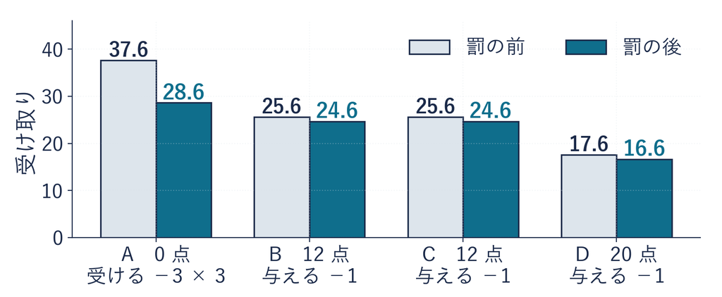

- **罰の前**：20 − 出した点 ＋ 箱の分け前 17.6（箱の合計 44 × 1.6 ÷ 4）
- **罰の後**：A は −3 × 3 件、B・C・D は −1（消えた点は 12）

一人あたりの受け取りは 26.6 → 23.6（入口の答えは ③）

## 純利得

**純利得：罰で消えた点を引いた、皆の受け取り**

定義

**純利得** ＝ **費用前利得** − **制度費用**

- **費用前利得**：罰の前の受け取りの、4 人の平均
- **制度費用**：罰のルール（制度）で消えた点 ＝（実施費用 1 ＋ 損失 3）× 罰の件数 ÷ 人数
- **実施費用**：与えた人の手間（−1）／**損失**：受けた人の損（−3）

費用前利得 ＝ 20 − 班平均 ＋ 1.6 × 班平均 ＝ 20 ＋ 0.6 × 班平均（1 点で自分 −1・箱から ＋1.6）

今回の班

$26.6 - (1 + 3) \times 3 \div 4$

$= 23.6$

消えた 12 点を 4 人で

## 罰への反応

罰で行動がどう変わるかは、モデルが勝手に決めない。作る人が 2 つ書く

ルール 1罰を受けた人は、次から他の 3 人の平均に合わせる（× 1）

ルール 2罰が起きた班の条件付き協力型は、合わせる割合 0.8 を 1 にする

[figure not shown]

2 ラウンド目の罰は 0 件（線 14 − 4 ＝ 10 を、B と C の 10.67 は下回らない）

罰への反応も、作る人が書く

## Q&A

Q1 協力が増えたなら、それで成功では？

班の 1 ラウンド目は、拠出が罰なしと同じでも受け取りは **26.6 → 23.6**  
協力の数だけ見ると、消えた 12 点が見えない

Q2 点が消えると、何が困る？

罰は誰の手にも渡らない。罰が多いほど、皆の受け取りが減る  
罰が 0 件のラウンドは費用も 0（班の 2 ラウンド目）

Q3 与えた人の手間だけ引けばよいのでは？

26.6 − 0.75 ＝ 25.85 ✕（受けた人の損 9 点を数えていない）  
手間 3 ＋ 損 9 ＝ 12 点を両方引いて 23.6

## 100 人の 1 ラウンド目の帳簿

今度は 100 人で、同じ罰のルールを。1 ラウンド目の拠出は罰なしと同じ 9.2

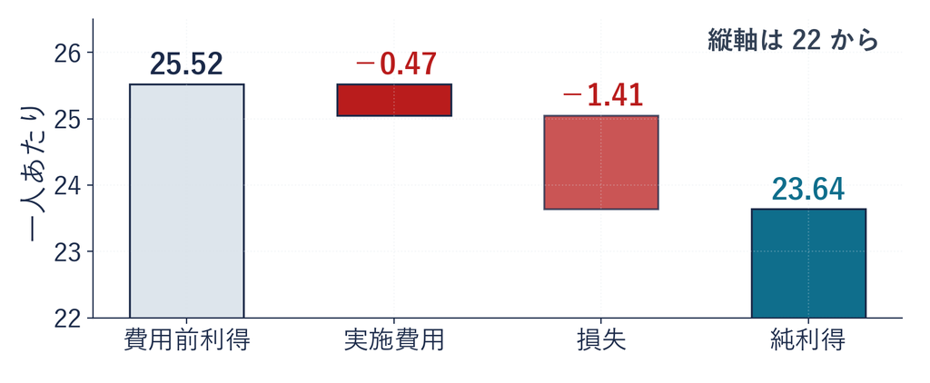

費用前利得20 ＋ 0.6 × 9.2 ＝ 25.52

制度費用47 件 ×（1 ＋ 3）÷ 100 ＝ 1.88（実施 0.47 ＋ 損失 1.41）

純利得25.52 − 1.88 ＝ 23.64（手間だけ引くと 25.05 ✕）

## デモ：罰の帳簿

数の話

純利得 ＝ 費用前利得 − 制度費用（実施費用 ＋ 損失）

- **何を見るか**：罰あり・反応ありの社会の、  
  1ラウンドごとの帳簿（一人あたり）
- **図の意味**：左＝そのラウンドの帳簿の棒・破線＝罰なしの社会の、  
  そのラウンドの受け取り・右＝罰の件数
- **操作**：次のラウンドへ進む／1ラウンド戻す  
  （今は『罰の帳簿』のタブだけ触る）

ミッション 純利得が罰なしを初めて上回るラウンドを探す

※ 次のスライドへ進むときは、デモの枠の外を一度クリックしてから ← → キーを押す

[interactive chart not shown]

## 罰ありの 10 ラウンド

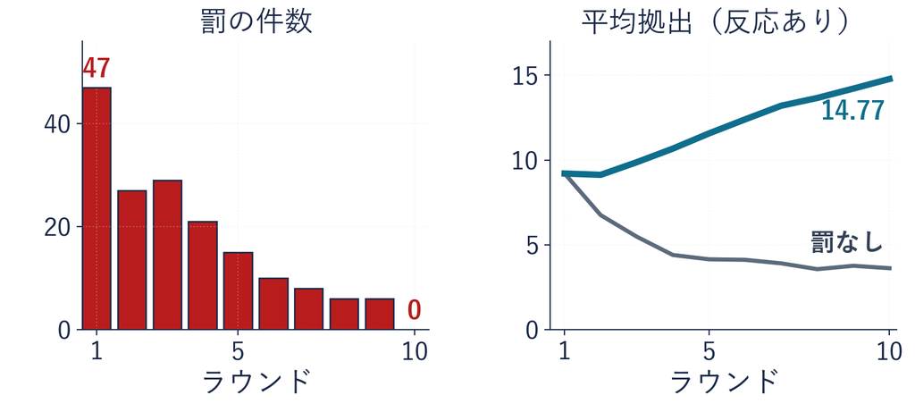

罰 47 件 → 10 ラウンド目 0 件・拠出 9.2 → 10 ラウンド目 14.77

デモの答え：純利得は 2 ラウンド目から罰なしより上（24.39 ＞ 24.05）

## 10 ラウンド平均の帳簿

| 社会 | 拠出 | 費用前利得 | 制度費用 | 純利得 |
| --- | --- | --- | --- | --- |
| 罰なし | 4.89 | 22.94 | 0.00 | 22.94 |
| 罰・反応あり | 11.86 | 27.12 | 0.68 | 26.44 |

協力の数と、皆の受け取りの数は別に数える

拠出の差 4.89 → 11.86 を生んだのは  
① 罰のルール ② 反応のルール ③ まだ分からない

動画を止めて、①〜③から 1 つ選んで、少し考えてから再生

## 班の帳簿の写経

```python
c = [0, 12, 12, 20]                    # A・B・C・D の拠出
avg = sum(c) / 4                       # 班平均
low = [x for x in c if x < avg - 4]    # 罰を受ける人
high = [x for x in c if x >= avg]      # 罰を与える人
n = len(low) * len(high)               # 罰の件数
gross = 20 + 0.6 * avg                 # 罰の前の受け取り
print(n, round(gross, 2), round(gross - n * (1 + 3) / 4, 2))
```

| 行 | 部品 | 中身 |
| --- | --- | --- |
| 1-2 | **① 班と平均** | 4 人の拠出のリストと、班平均（STEP 1） |
| 3-4 | **② 受ける人・与える人** | 平均 − 4 より下の人／平均以上の人（STEP 3・2） |
| 5 | **③ 件数** | 受ける人の数 × 与える人の数 |
| 6 | **④ 罰の前** | 費用前利得 20 ＋ 0.6 × 班平均（一人あたり） |
| 7 | **⑤ 表示** | 件数・罰の前・罰の後（1 件 4 点を 4 人で割って引く） |

## 班の帳簿の実行

1. 段 2 の写経の下に  
   **＋ コード**でセルを足す
2. p.35 のコードを  
   上から写す
3. **▶** か **Shift + Enter** で実行  
   （Mac は Shift + return）
4. 1 行の出力で  
   件数と受け取りを見る

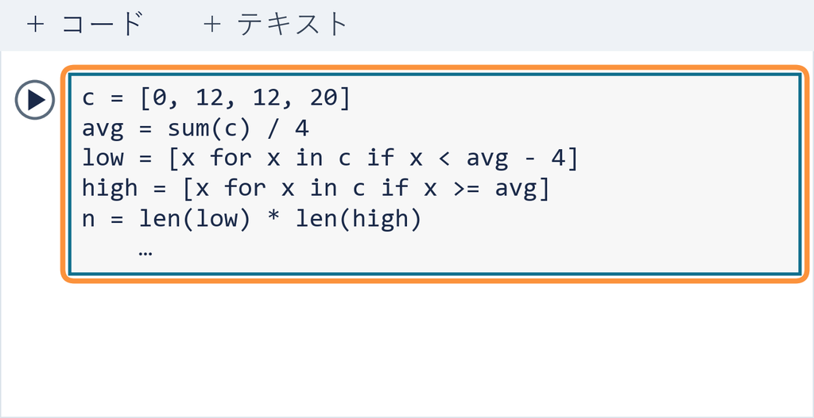

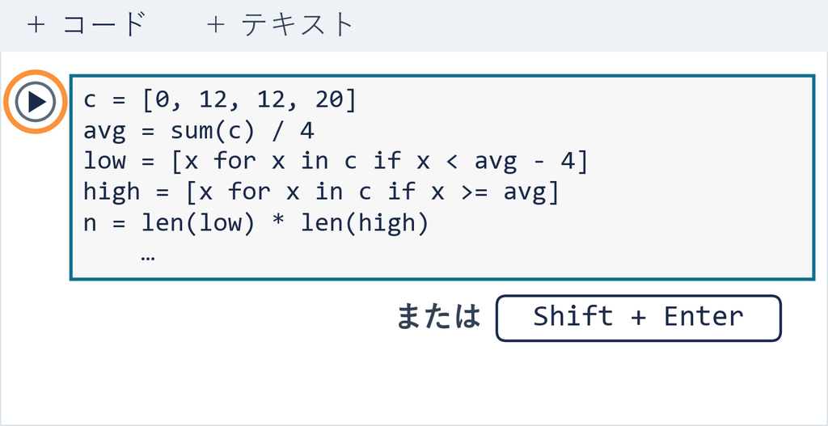

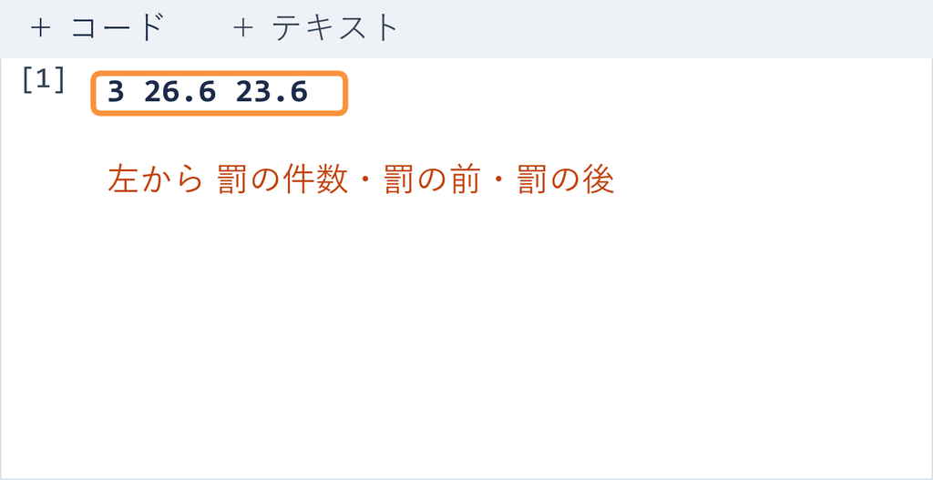

⏸ PAUSE 動画を止めて $5$ 分。1 行が出たら再生に戻る

## 罰ありの帳簿の実行

```python
rec = society(punishment=True)         # 100人・罰あり（反応あり）
print("拠出:", mean_of(rec, "contribution"),
      " 費用前:", mean_of(rec, "gross"))
print("費用:", mean_of(rec, "cost"), " 純利得:", mean_of(rec, "net"))
```

ノート段 2 の【そのまま実行】のセル。写さずに選んで ▶（段 1 の 2 つのセルを先に）  
punishment=True で罰のルールが入る（反応のルールも既定で入る）  
`" 費用前:"` の頭の半角スペースは、出力で前の数との間を空けるため

出力 拠出: 11.86 費用前: 27.12  
費用: 0.68 純利得: 26.44

⏸ PAUSE 動画を止めて $2$ 分。2 行が出たら再生に戻る

## 演習 2 班の入れ替え

p.36 の出力 3 26.6 23.6

演習 2

班を [0, 4, 12, 20] にすると、罰と受け取りはどう変わるか

```python
c = [0, 12, 12, 20]                    # ← ここを書き換える
avg = sum(c) / 4                       # 班平均
low = [x for x in c if x < avg - 4]    # 罰を受ける人
high = [x for x in c if x >= avg]      # 罰を与える人
n = len(low) * len(high)               # 罰の件数
gross = 20 + 0.6 * avg                 # 罰の前の受け取り
print(n, round(gross, 2), round(gross - n * (1 + 3) / 4, 2))
```

1. **書き換える**：p.35 の 7 行を写し（上のセルをコピーしてよい）  
   1 行目を c = [0, 4, 12, 20] に
2. **予想する**：罰は何件か。消える点は 12 点より多いか
3. **終わり**：1 行が出たら、答え欄に 3 つの数を書く

⏸ PAUSE 動画を止めて $5$ 分。1 行が出たら再生に戻る

## 演習 2 の答え

c = [0, 4, 12, 20]  
4 25.4 21.4

- **班平均** 9：受ける人は 5 より下の 0 と 4・与える人は 12 と 20
- **罰 4 件・16 点が消える**：受け取りは 25.4 → 21.4  
  前の班より、罰の前は −1.2（26.6 → 25.4）・罰の後は −2.2（23.6 → 21.4）

低い人が 1 人増えると、罰の件数も消える点も増える

## まとめ

- **純利得**：罰で消えた点を引いた、皆の受け取り
- **4 人の班**：1 ラウンド目は 26.6 → 23.6（費用だけかかる）
- **100 人の社会**：拠出 4.89 → 11.86・純利得 22.94 → 26.44

分析する人として言えること：罰には消える費用がある。  
協力の数と皆の受け取りは別に数える  
まだ言えないこと：増えた分は、  
罰のルールから来たのか、書いた反応から来たのか  
これを次のトピックで見る

経済プログラミング特論II

第6回 — Topic03

対照条件と行動反応

罰の効き目は、書いた反応から来る

## 今日の道のり

**今日のゴール**：分析する人として、罰を足すと協力は増えるか、皆は得をするかに答える  
罰で消えた点を引いて数え、1 つずつ止めて比べる

1

罰なしの社会を回す

実習：写経 4 人の班を回す

実習：実行 100 人の社会

演習 1 割合を 1.0 に

2

罰の帳簿をつける

実習：写経 班の帳簿

実習：実行 罰ありの帳簿

演習 2 班を替える

3

反応を止めて比べる

実習：写経 反応だけ止める

実習：実行 3 つの社会の図

演習 3 受けた人だけ反応

4

費用と持ち出し方

実習：写経 費用を 4 通りに

演習 4 費用 22 と 1 文

いまココ。反応だけ止めて、**3 つの社会を比べる**

## このトピックで学ぶこと

- **ここまで**：罰を足すと、拠出 4.89 → 11.86・純利得 22.94 → 26.44  
  協力も、皆の受け取りも上がった
- **でも**：あなたの教室に注意のルールを作り、皆が出すようになっても  
  ルールのおかげか、注意された人が素直だったからかは分からない
- **問い**：分析する人として、協力を増やしたのは  
  罰のルールか、罰への反応かを確かめる
- **見るもの**：罰なし・反応あり・反応なしの 3 本の線と、3 行の帳簿  
  分かると、報告に「効き目はどこから来たか」が書ける
- **進め方**：前半は同じ 4 人の班で反応だけ止め、後半は 100 人の社会を 3 つ並べる

そこで、前に出てきた「条件を 1 つだけ変える」を、**片方だけ**に当ててみる

## 反応だけ止めた班の拠出

罰のルールはそのまま、反応だけ止める  
4 人の班の 2 ラウンド目の拠出は

- **①** 罰なしより上
- **②** 罰なしと同じ
- **③** 罰なしより下

動画を止めて、①〜③から 1 つ選んで、少し考えてから再生

## 4 人の班の 3 つの社会

1 ラウンド目は 3 つとも 0・12・12・20（罰ありは A が 3 件）  
反応なしの 2 ラウンド目からは、班平均以上の D だけが A に 1 件

[figure not shown]

反応なしの 2・3 ラウンド目の拠出は、罰なしと同じ（入口の答えは ②）

## よくある失敗 罰のルールだけを見た結論

✕ 罰のルールを加えれば、協力は増える

罰を加えた社会だけ、拠出が増えた  
だから罰のルールが効いた、と読む

○ 反応だけ止めると、増えない

A は 0 のまま、B と C は罰なしと同じ  
罰は続き、受け取りは罰なしより下

協力を増やしたのは、罰を受けたら合わせると書いた仮定

p.34 の問い（4.89 → 11.86 を生んだのはどれか）の答えは「③ まだ分からない」だった  
片方だけ止めて比べると「② 反応のルール」

## 対照条件

**対照条件：効いたのはどれか、1 つずつ止めて確かめる**

定義

**対照条件**調べたいもの 1 つだけを止め  
ほかは全部同じにした比べる相手

| 社会 | 罰のルール | 反応のルール |
| --- | --- | --- |
| 罰なし | なし | なし |
| 罰・反応あり | あり | あり |
| 罰・反応なし（対照条件） | あり | **なし** |

反応のルール：① 罰を受けた人は次から合わせる  
② 罰が起きた班の条件付き協力型（見た人）も × 1

ほかは全部同じ（同じ 4 人・同じ罰の決め方・同じ 3 ラウンド）

## 反応の仮定と観測

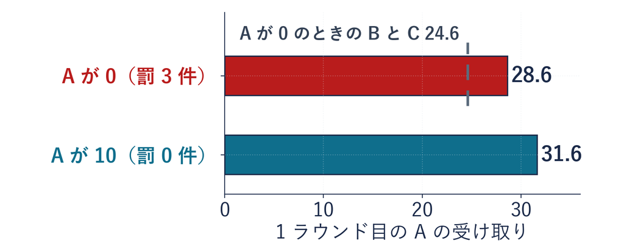

- **いまの A**：0 を出して罰 3 件、受け取りは罰の前の 37.6 − 3 × 3 ＝ 28.6
- **損得なら**：A が 10 出すと班平均 13.5 で、罰の線（平均 − 4）は 9.5  
  10 は線を超えるので罰 0 件、受け取りは 20 − 10 ＋ 54 × 1.6 ÷ 4 ＝ 31.6（54 は班の合計）
- **このモデルの A**：損得を計算しない。合わせるのは、そう書いたから

反応ありの数は、人がこう反応するという証拠ではない

## 3 つの社会の拠出

今度は 100 人で、同じ 3 つの社会を。seed を同じにして、同じ 100 人・同じ組み方  
1 ラウンド目はどれも 9.2・線の端の数は 10 ラウンド目の値

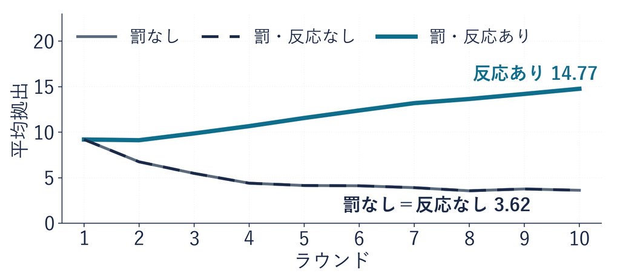

反応なしの線は、罰なしの線と 10 ラウンドとも重なる

## デモ：3 つの社会

数の話

対照条件：罰のルールは残し、  
反応の2つのルールだけを止めた比べる相手

- **何を見るか**：罰なし・罰と反応あり・罰と反応なし  
  （同じ seed＝同じ100人・同じ組み方）
- **図の意味**：横軸＝ラウンド・縦軸＝平均拠出か純利得
- **操作**：拠出／純利得・社会のボタン

ミッション 純利得の画面で、拠出が重なる 2 本を見比べる

※ 次のスライドへ進むときは、デモの枠の外を一度クリックしてから ← → キーを押す

[interactive chart not shown]

## 3 つの社会の帳簿

| 社会 | 拠出 | 費用前利得 | 制度費用 | 純利得 | 罰の件数 |
| --- | --- | --- | --- | --- | --- |
| 罰なし | 4.89 | 22.94 | 0.00 | 22.94 | 0 |
| 罰・反応あり | 11.86 | 27.12 | 0.68 | 26.44 | 169 |
| 罰・反応なし | 4.89 | 22.94 | 1.11 | 21.82 | 278 |

反応を止めると、増えた 6.97 がまるごと消える

反応なしは拠出が罰なしと同じで、制度費用 1.11 だけかかる  
点は一人・一ラウンドの平均、罰の件数は 100 人・10 ラウンドの合計

## 罰の件数

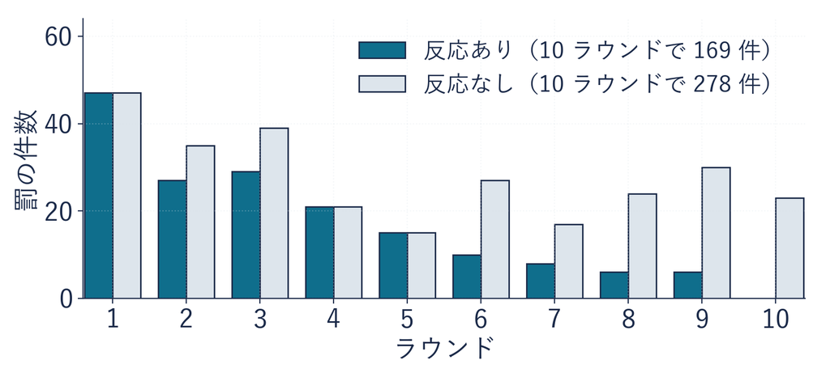

反応ありは 47 → 0 件、反応なしは 15〜47 件が続く。4 人の班も 3 件対 5 件

罰が減るのも、反応の仮定から

## 制度の効き目の調べ方

手順

STEP 1同じ seed で、罰なしを回す

STEP 2罰を足して回す（反応のルールも加えて）

STEP 3罰は残して反応だけ止めて回す（対照条件）

STEP 4拠出と純利得を、別々に比べる

STEP 3 の比べる相手が、効き目の出どころを分ける

## 反応だけ止める写経

```python
none = society()                                   # 罰なし
resp = society(punishment=True)                    # 罰・反応あり
noresp = society(punishment=True, response=False)  # 罰・反応なし
for name, rec in [("罰なし", none), ("反応あり", resp),
                  ("反応なし", noresp)]:
    print(name, mean_of(rec, "contribution"), mean_of(rec, "net"),
          sum(r["sanctions"] for r in rec))
```

| 行 | 部品 | 中身 |
| --- | --- | --- |
| 1-3 | **① 3 つの社会** | 同じ seed で 3 回。response=False で反応だけ止める |
| 4-5 | **② 繰り返し** | 名前と記録 rec（1 ラウンドごとの記録の並び） の組を、1 つずつ取り出す |
| 6-7 | **③ 表示** | 拠出・純利得（mean_of＝10 ラウンドの平均） r[“sanctions”]（罰の件数）を 10 ラウンド足した数 |

## 反応だけ止めるコードの実行

1. 段 1 の 2 つのセルを ▶  
   してから  
   **＋ コード**で  
   セルを足す
2. p.55 のコードを  
   上から写す
3. **▶** か **Shift + Enter** で実行  
   （Mac は Shift + return）
4. 3 行の出力で  
   拠出と純利得を見る

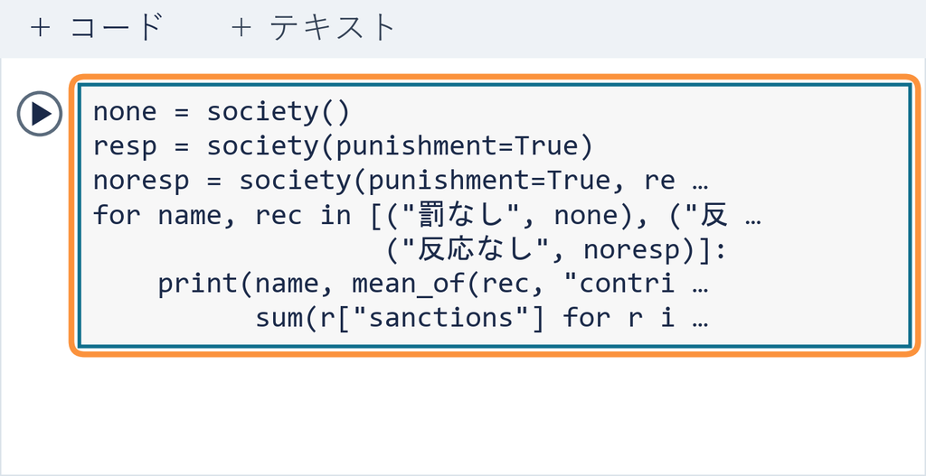

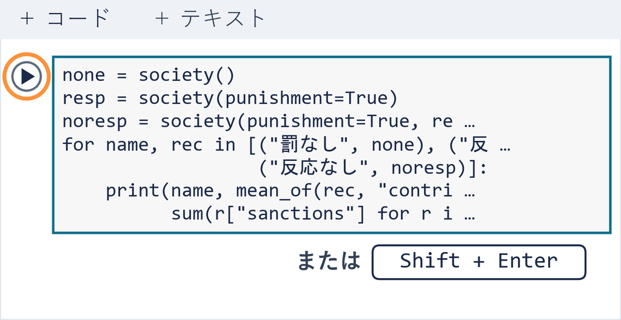

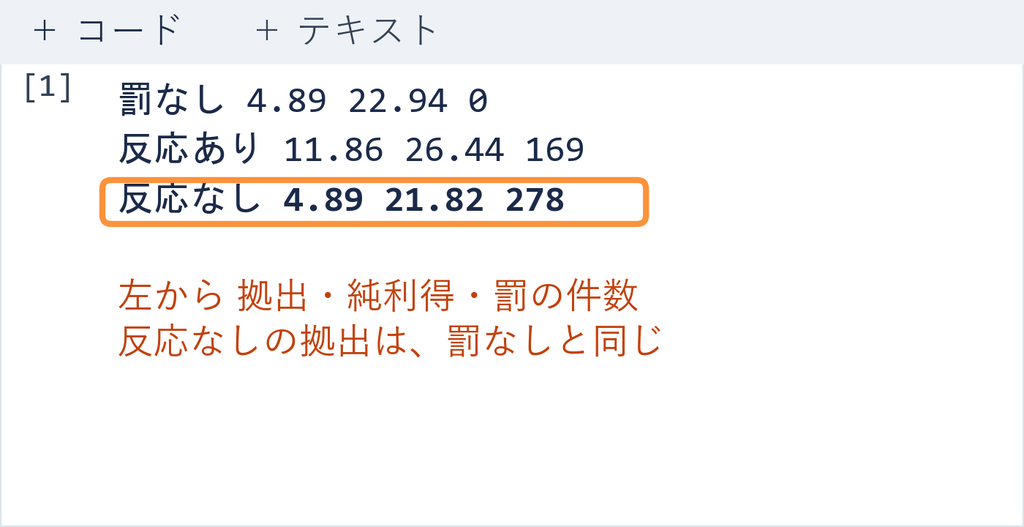

⏸ PAUSE 動画を止めて $5$ 分。3 行が出たら再生に戻る

## 3 つの社会の図の実行

```python
!pip install japanize-matplotlib
import japanize_matplotlib
import matplotlib.pyplot as plt
for name, rec, ls in [("罰なし", none, "-"), ("反応あり", resp, "-"),
                      ("反応なし", noresp, "--")]:
    plt.plot(range(1, 11), [r["contribution"] for r in rec], ls, label=name)
plt.xlabel("ラウンド")
plt.ylabel("平均拠出")
plt.legend()
plt.show()
```

ノート段 3 の【そのまま実行】のセル。写さずに選んで ▶（p.55 の写経のセルを先に）  
1・2 行目は Colab で日本語を出すための 2 行（同じノートでは一度でよい）

出力 p.49 と同じ形の図（反応なしの破線が、罰なしの線に重なる）

⏸ PAUSE 動画を止めて $2$ 分。図が出たら再生に戻る

## 演習 3 受けた人だけの反応

p.56 の出力 反応なし 4.89 21.82 278

演習 3

罰を受けた人の反応だけ残すと、拠出はどこまで戻るか

```python
rec = society(punishment=True, response=False)  # ← ここを書き換える
print("拠出:", mean_of(rec, "contribution"), " 純利得:", mean_of(rec, "net"),
      " 罰:", sum(r["sanctions"] for r in rec))
```

反応のルールの切り替え：punished_rule＝① 受けた人・witness_rule＝② 見た人（False で止める）

1. **書き換える**：3 行を写し、1 行目を（response は書かない）  
   rec = society(punishment=True, witness_rule=False) に
2. **予想する**：拠出は 4.89 と 11.86 の、どちらに近いか
3. **終わり**：1 行が出たら、答え欄に 3 つの数を書く

⏸ PAUSE 動画を止めて $5$ 分。1 行が出たら再生に戻る

## 演習 3 の答え

rec = society(punishment=True, witness_rule=False)  
拠出: 10.71 純利得: 25.43 罰: 248

- **拠出 10.71**：11.86 に近い（増えた 6.97 の 8 割ほど）
- **見た人の反応だけ**なら 5.87（punished_rule=False）

増えた分の大半は、罰を受けた人が合わせると書いたこと

## まとめ

- **対照条件**：効いたのはどれか、1 つずつ止めて確かめる
- **4 人の班**：反応を止めると、2・3 ラウンド目は罰なしと同じ
- **100 人の社会**：反応なしは拠出 4.89・純利得 21.82（罰 278 件）

分析する人として言えること：このモデルでは、罰の効き目は書いた反応から来る  
まだ言えないこと：罰の手間を大きくしたら、注意が減る動きは出てくるか  
これを次のトピックで見る

経済プログラミング特論II

第6回 — Topic04

感度分析と外的妥当性

書いていない反応は、計算しても出てこない

## 今日の道のり

**今日のゴール**：分析する人として、罰を足すと協力は増えるか、皆は得をするかに答える  
罰で消えた点を引いて数え、1 つずつ止めて比べる

1

罰なしの社会を回す

実習：写経 4 人の班を回す

実習：実行 100 人の社会

演習 1 割合を 1.0 に

2

罰の帳簿をつける

実習：写経 班の帳簿

実習：実行 罰ありの帳簿

演習 2 班を替える

3

反応を止めて比べる

実習：写経 反応だけ止める

実習：実行 3 つの社会の図

演習 3 受けた人だけ反応

4

費用と持ち出し方

実習：写経 費用を 4 通りに

演習 4 費用 22 と 1 文

いまココ。費用を変えて、**持ち出し方を決める**

## このトピックで学ぶこと

- **ここまで**：反応だけ止めると、拠出は罰なしと同じ  
  このモデルでは、罰の効き目は書いた反応から来た
- **でも**：あなたの教室でも、点を出さない人に注意するのは手間で気まずい  
  手間が大きいと、注意する人は減りそう
- **問い**：分析する人として、罰の手間をいくらまで上げても  
  罰ありのほうが皆の受け取りが多いかを確かめる
- **見るもの**：手間 1・5・20・25 の拠出と純利得の表（罰なしと並べる）  
  分かると、報告に「この仮定なら」の 1 文が書ける
- **進め方**：前半は 4 人の班で手間を 1 点 → 25 点に、後半は 100 人で 4 通りに

そこで、前に出てきた感度分析で、**手間だけ**を変えてみる

## 罰の手間を上げた班の拠出

罰 1 件で与えた人が失う点（実施費用・以下「費用」）を  
1 点から 25 点に上げる（受けた人の −3 はそのまま）  
4 人の班の 2・3 ラウンド目の拠出は

**①** 下がる **②** 変わらない **③** 上がる

動画を止めて、①〜③から 1 つ選んで、少し考えてから再生

## 4 人の班の費用 25

1 ラウンド目は 0・12・12・20 で、B・C・D が A へ 1 件ずつ（罰は 3 件）

[figure not shown]

3 件 ×（25 ＋ 3）＝ 84 点が消え、班の平均は 5.6（費用 1 なら 23.6・罰の前 26.6）

受け取りは 0 より下にもなる（次のラウンドは、また持ち点 20 から）

## 費用 25 の班の 2・3 ラウンド目

| ラウンド | 費用 1 の A・B・C・D | 費用 25 の A・B・C・D |
| --- | --- | --- |
| 2 | 14.67・10.67・10.67・20 | 14.67・10.67・10.67・20 |
| 3 | 13.78・15.11・15.11・20 | 13.78・15.11・15.11・20 |

費用を 25 にしても、拠出は同じ（入口の答えは ②）

罰のルール平均以上の人が、平均より 4 を超えて低い人へ 1 件ずつ

反応のルール罰を受けた人は次から合わせ、罰が起きた班の条件付き協力型も × 1

罰のルールにも反応のルールにも、費用は出てこない  
罰を与える側の「手間が大きいと罰をやめる」は、どこにも書いていない

書いていない反応は、計算しても出てこない

## Q&A

Q1 費用を上げても拠出が同じ。だから人は費用を気にしない？

✕ 気にしないのは、作る人が書いたルール  
調べたいなら「手間が大きいと注意しない」を書き足す

Q2 実験の日、2 回目は平均が下がった。それも罰の話？

✕ 2 回目は、1 回目の集計を見たあとに選び直した回。罰は無かった  
モデルの罰の結果で、教室の動きを説明しない

書いていない動きは、書き足してから確かめる

## 外的妥当性

**外的妥当性：モデルの答えは、書いたルールの中だけ**

定義

**外的妥当性**モデルや実験の結果を、別の場所・  
別の人・別の時に持ち出してよい範囲

- **確かめた**：この仮定なら、罰なしと罰ありで拠出と純利得に差が出る
- **確かめていない**：現実の人が、罰や手間にどう反応するか

持ち出してよい範囲に、そう名前を付けた

## 費用ごとの拠出と純利得

今度は 100 人で、費用を 1・5・20・25 に。同じ seed・同じルールで、費用だけ変える

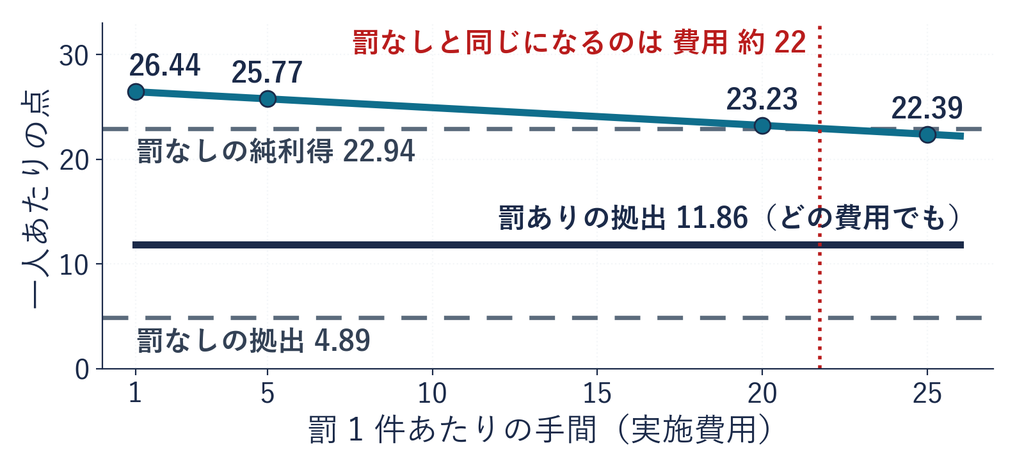

拠出は 11.86 のまま、純利得は費用 約 22 で罰なしを下回る

seed を 20 通り変えると、費用 25 で罰なしより下は 20 本中 9 本（seed 1 つだけでは言い切れない）  
班の 5.6 は罰 3 件の 1 ラウンドだけの数。100 人は、罰が減っていく 10 ラウンドの平均

## 結果の持ち出し方

手順

STEP 1「この仮定なら」を付けて、結果を 1 文にする

STEP 2費用を変えても中身を変えなかったルールを  
書き出す（固定した行動ルール）

STEP 3現実で確かめる、次の観測を書く

例 罰を受けた人が合わせるという仮定なら  
費用 1 では純利得が罰なしより上、費用 25 では下  
固定した行動ルールの例：罰を与える人は、手間が大きくても与える  
次の観測の例：罰を受けた人が次に出す点を測る

STEP 2 を書くと、モデルが答えられない問いが見える

## 費用を 4 通りに替える写経

```python
base = mean_of(society(), "net")            # 罰なしの純利得
print("罰なし", base)
for c in [1, 5, 20, 25]:                    # 費用だけを変える
    rec = society(punishment=True, cost=c)  # 罰あり（反応あり）
    print(c, mean_of(rec, "contribution"), mean_of(rec, "net"))
```

| 行 | 部品 | 中身 |
| --- | --- | --- |
| 1-2 | **① 比べる相手** | 罰なしの純利得（10 ラウンドの平均）を base に |
| 3-4 | **② 費用だけ変える** | c に 1・5・20・25 を順に入れ、cost=c で回す |
| 5 | **③ 表示** | 費用・拠出・純利得（10 ラウンドの平均） |

## 費用を替えるコードの実行

1. 段 1 の 2 つのセルを ▶  
   してから  
   **＋ コード**で  
   セルを足す
2. p.71 のコードを  
   上から写す
3. **▶** か **Shift + Enter** で実行  
   （Mac は Shift + return）
4. 5 行の出力で  
   拠出と純利得を見る

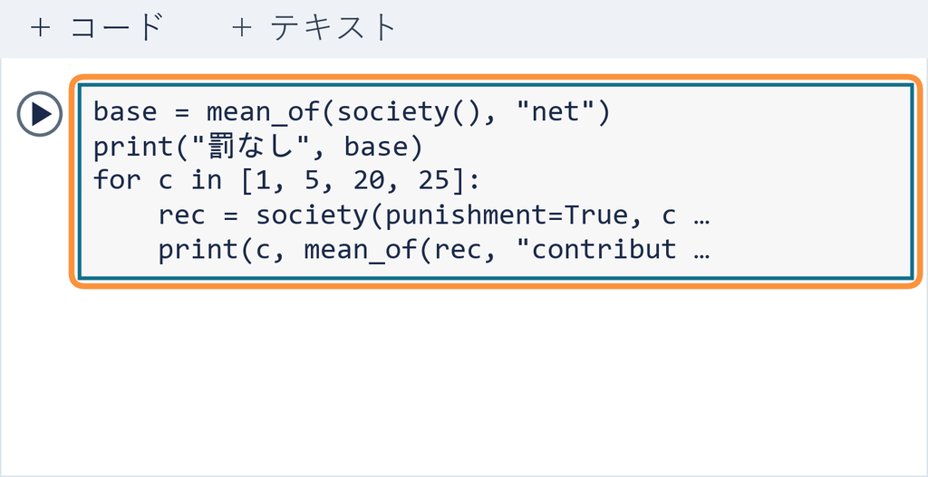

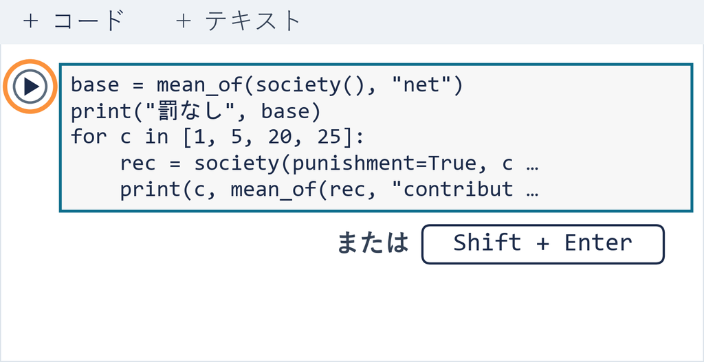

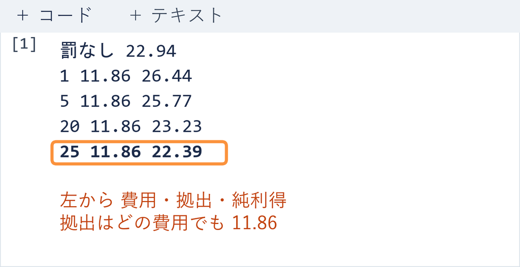

⏸ PAUSE 動画を止めて $5$ 分。5 行が出たら再生に戻る

## 演習 4 費用 22 の持ち出し

p.72 の出力 25 11.86 22.39

演習 4

費用 22 では、純利得は罰なしより上か下か

```python
rec = society(punishment=True, cost=1)  # ← ここを書き換える
print("拠出:", mean_of(rec, "contribution"), " 純利得:", mean_of(rec, "net"),
      " 罰なし:", base)
```

1. **書き換える**：3 行を写し、1 行目を cost=22 に
2. **予想する**：純利得は、罰なしの 22.94 より上か下か
3. **書く**：答え欄に「この仮定なら」の 1 文・固定した行動ルール 1 つ・  
   次の観測（現実で確かめる問い）1 つ

base は p.71 の写経のセルで作ったもの

⏸ PAUSE 動画を止めて $7$ 分。1 行と 3 つの文を書いたら再生に戻る

## 演習 4 の答え例

rec = society(punishment=True, cost=22)  
拠出: 11.86 純利得: 22.89 罰なし: 22.94

- **22.89 は 22.94 より下**：費用 22 で、罰なしをわずかに下回る
- **1 文**：罰を受けた人が合わせるという仮定なら、費用 22 で罰なしより下
- **固定した行動ルール**：手間がいくら大きくても、罰を与える人は与える
- **次の観測**：手間が大きいと、注意する人が減るかを尋ねる

## 今日のまとめ

分析する人として、この回でできるようになったこと

**ルールで社会を作る**人の代わりにルールを書いて、罰なしの社会を回す

**消えた点を引く**罰で消えた点を引いて、皆の受け取りを数える

**1 つずつ止める**反応だけ止めて、効き目の出どころを確かめる

**この仮定なら**手間を変えて、結果を「この仮定なら」で持ち出す

分析する人として言えること：書いていない反応は、計算しても出てこない  
まだ言えないこと：同じ公共財のルールで、別の決め方をする相手と比べたら  
やること：演習 1〜4 の答え欄を書いて、いつもの手順で提出